# Project_Final

# Representation of Cholesterol level

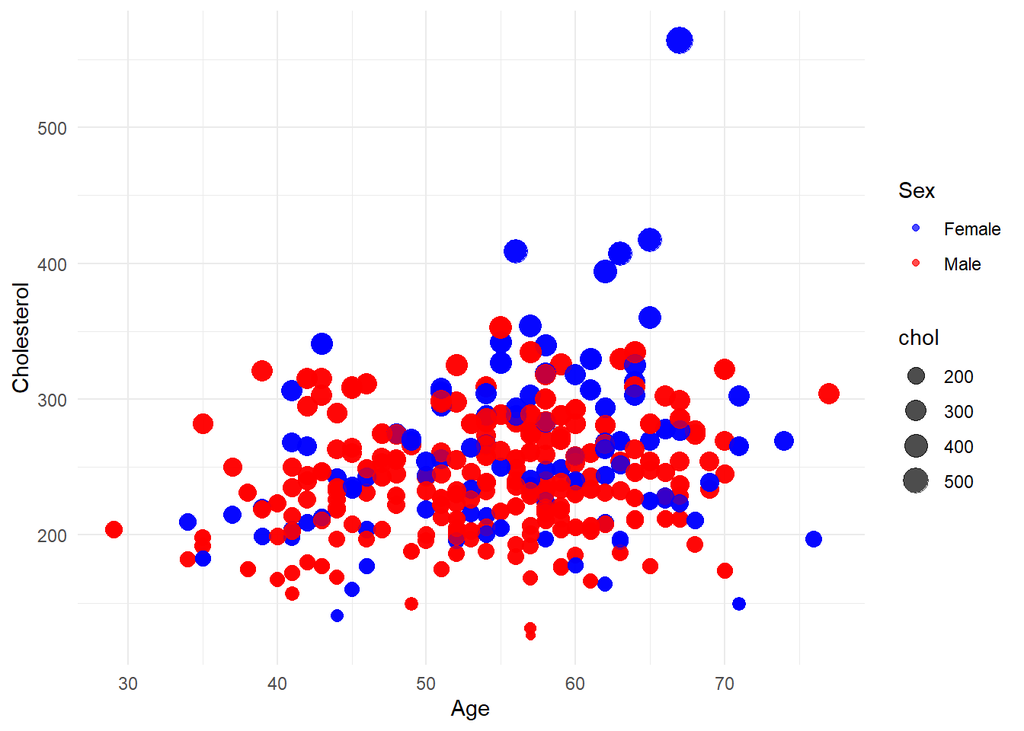

```r
library(ggplot2)

# Modify the plot
data2 %>%
  ggplot(aes(x = age, y = chol, color = sex, size = chol)) +
  geom_point(alpha = 0.7) +
  labs(x = "Age", y = "Cholesterol", color = "Sex") +  # Change axis and legend labels
  scale_color_manual(values = c("blue", "red"), labels = c("Female", "Male")) +  # Customize color scale
  scale_size_continuous(range = c(2, 6)) +  # Adjust point size range
  theme_minimal()  # Use minimal theme for cleaner appearance
```

The image shows a scatter plot with “Age” on the x-axis and “Cholesterol” on the y-axis. The data points are color-coded to represent two different sexes: blue for female and red for male. Additionally, the size of each data point corresponds to different cholesterol levels, with larger dots indicating higher cholesterol levels.

# Comparison of Blood pressure across pain type

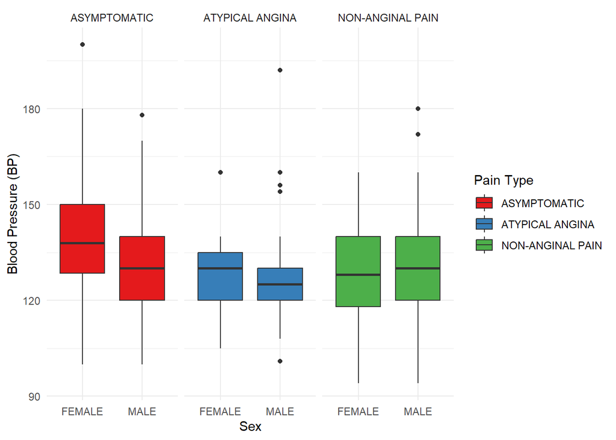

```r
library(ggplot2)

# Modify the plot
data2 %>%
  ggplot(aes(x = sex, y = trestbps, fill = factor(cp))) +
  geom_boxplot() +
  scale_fill_brewer(palette = "Set1") +  # Use a color palette for pain types
  labs(x = "Sex", y = "Blood Pressure (BP)", fill = "Pain Type") +  # Change axis and legend labels
  theme_minimal() +  # Use minimal theme for a cleaner appearance
  facet_grid(~cp)  # Facet by pain type
```

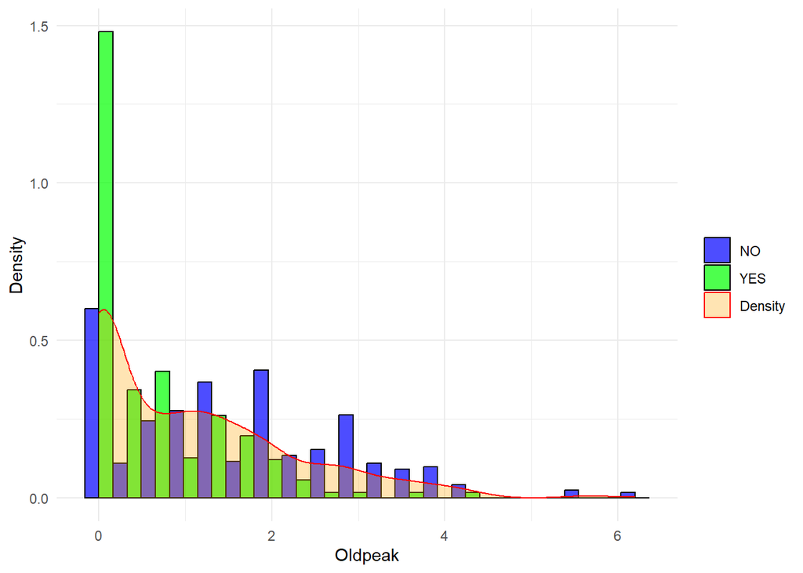

```r
library(ggplot2)

ggplot(data2) +
  geom_histogram(aes(x = oldpeak, y = ..density.., fill = target),
                 position = "dodge", color = "black", alpha = 0.7, bins = 20) +
  geom_density(aes(x = oldpeak, fill = "Density"), alpha = 0.3, color = "red") +
  scale_fill_manual(values = c("NO" = "blue", "YES" = "green", "Density" = "orange")) +
  labs(x = "Oldpeak", y = "Density", fill = "") +  # Adjust axis labels and legend title
  theme_minimal()  # Use minimal theme for cleaner appearance
```

The histogram bars show the distribution of the Oldpeak values for two different groups (YES and NO). The height of each bar corresponds to the density (or frequency) of observations within that range of Oldpeak values. The density plot, which is represented by a red line, shows the probability density function of the Oldpeak variable, giving a sense of the continuous probability distribution across the values.

```r
library(corrplot)
# Calculate the correlation matrix
cor_heart <- cor(data2[, 10:14])

# Display the correlation matrix
cor_heart
```

```
##                 age    trestbps        chol     thalach     oldpeak
## age       1.0000000  0.27112141  0.21982253 -0.39022708  0.20813668
## trestbps  0.2711214  1.00000000  0.12797743 -0.03926407  0.18743411
## chol      0.2198225  0.12797743  1.00000000 -0.02177209  0.06488031
## thalach  -0.3902271 -0.03926407 -0.02177209  1.00000000 -0.34979616
## oldpeak   0.2081367  0.18743411  0.06488031 -0.34979616  1.00000000
```

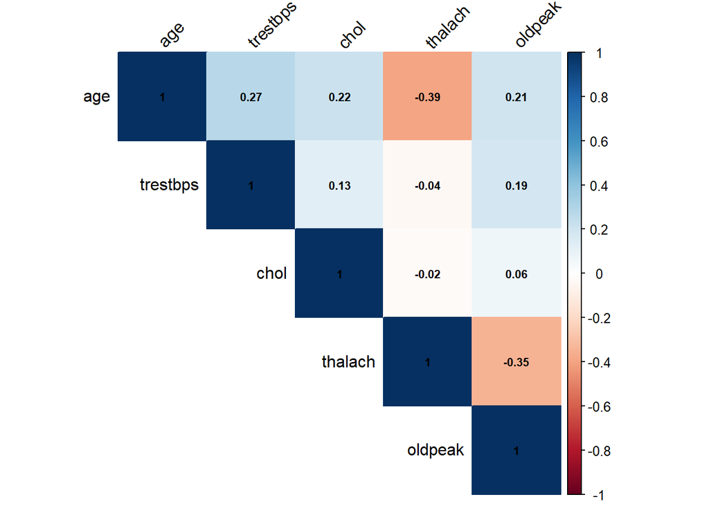

```r
# Plot the correlation matrix in a heatmap
corrplot(cor_heart, method = "color", type = "upper",
         tl.col = "black", tl.srt = 45,
         addCoef.col = "black", number.cex = 0.7)
```

The diagonal from the top left to the bottom right shows perfect correlations (1.0) because these are the variables correlated with themselves. ‘age’ has a moderate positive correlation with ‘trestbps’ (0.27) and a weak positive correlation with ‘chol’ (0.22). ‘thalach’ has a moderate negative correlation with ‘age’ (-0.39) and with ‘oldpeak’ (-0.35), indicating that as ‘age’ and ‘oldpeak’ increase, ‘thalach’ tends to decrease. ‘trestbps’ and ‘chol’ show very weak or no correlation with ‘thalach’ and ‘oldpeak’.

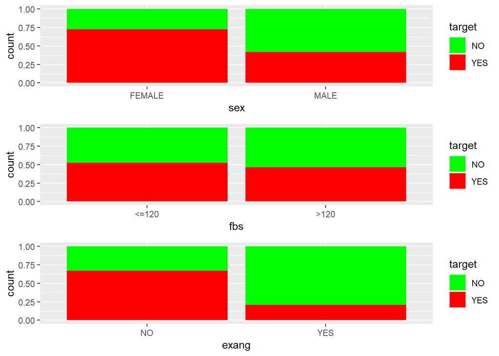

```r
library(gridExtra)
library(ggplot2)

# Define colors for "NO" and "YES"
colors <- c("NO" = "green", "YES" = "red")

grid.arrange(
  ggplot(data2, aes(x = sex, fill = target)) +
    geom_bar(position = "fill") +
    scale_fill_manual(values = colors),

  ggplot(data2, aes(x = fbs, fill = target)) +
    geom_bar(position = "fill") +
    scale_fill_manual(values = colors),

  ggplot(data2, aes(x = exang, fill = target)) +
    geom_bar(position = "fill") +
    scale_fill_manual(values = colors),

  nrow = 3
)
```

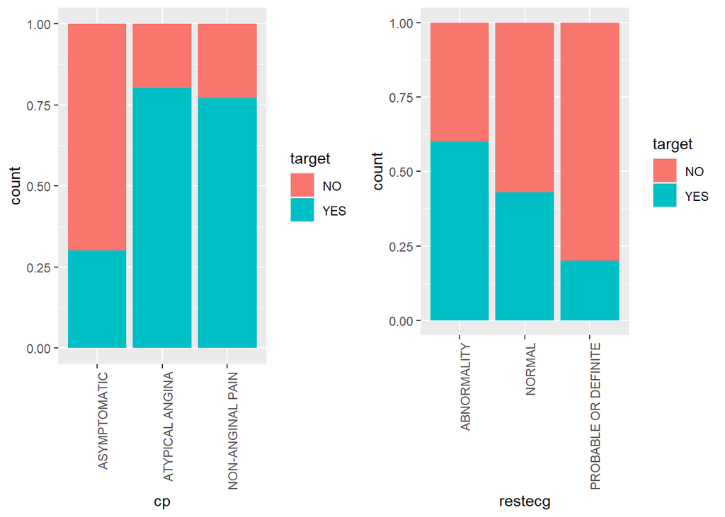

```r
grid.arrange(
  ggplot(data2, aes(x = cp, fill = target))+
  geom_bar(position = "fill")+ theme(axis.text.x = element_text(angle = 90, hjust = 1)),

  ggplot(data2, aes(x = restecg, fill = target))+
  geom_bar(position = "fill")+ theme(axis.text.x = element_text(angle = 90, hjust = 1)), ncol = 2
)
```

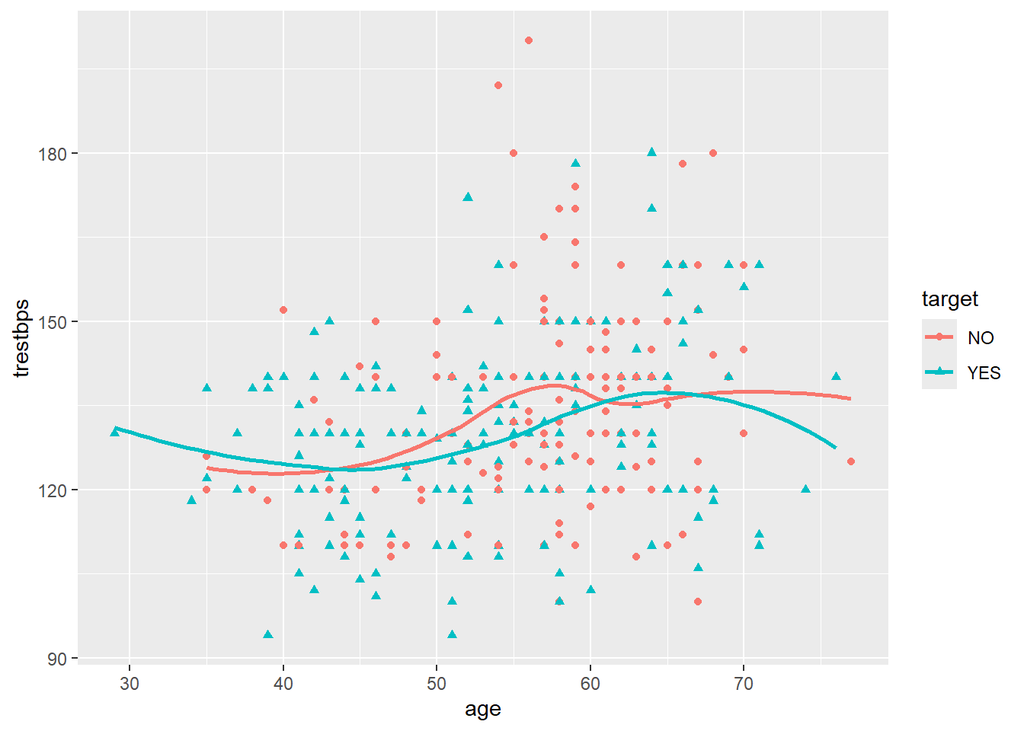

```r
ggplot(data2, aes(x = age, y = trestbps, color = target, shape = target)) +
  geom_point() +
  geom_smooth(method = "auto", se = FALSE)
```

Data points are plotted on the graph and are represented by two different shapes: triangles and dots.